# Module 1: Getting Started

MB 360: Scientific Inquiry in Microbiology At the Bench

Carlos C. Goller, Ph.D.

NC State University | Department of Biological Sciences

Camila Loyola, Graduate Teaching Assistant

2026-09-08

## Module 1: Getting Started

MB 360: Scientific Inquiry in Microbiology At the Bench

MB 360 Lab Workbook  
NC State University | Department of Biological Sciences

## Overview

**Week 1** · Lab safety · Pipetting fundamentals · First ELN entries

- Review Thomas Hall lab-safety rules and personal protective equipment
- Practice mechanical micropipettes and electronic multichannel pipettes
- Document results in the Electronic Lab Notebook (ELN)
- Build a team charter and communication plan

## Learning Outcomes

- **List** the personal protective equipment needed for MB 360
- **Identify** the features of the mechanical pipettes used in the course
- **Explain** how streak plating helps dilute bacteria
- **Describe** the advantages of electronic and multichannel pipettes
- **Create** a lab entry in the ELN system
- **Collect** and **interpret** pipetting data
- **Create** a team charter and communication plan

## Skills & Knowledge

Skills

- Follow basic safety precautions with live bacterial organisms
- Transfer liquid volumes reproducibly with pipettors
- Document protocols, observations, and results in an ELN
- Interpret variability in pipetting performance

Knowledge

- Pipettor types and their volume ranges
- PPE expectations for microbial work

## Lab Safety

**Important:** Treat all tips as potential biohazards at all times.

- **Before lab:** Wear lab coat, goggles, and gloves
- **During lab:**
  - Clean the bench before and after each session with 70% ethanol
  - Dispose of cultures and plates using designated biohazard procedures
- **After lab:** Remove PPE and decontaminate any personal items touched during lab

## Methods: Pipetting Practice

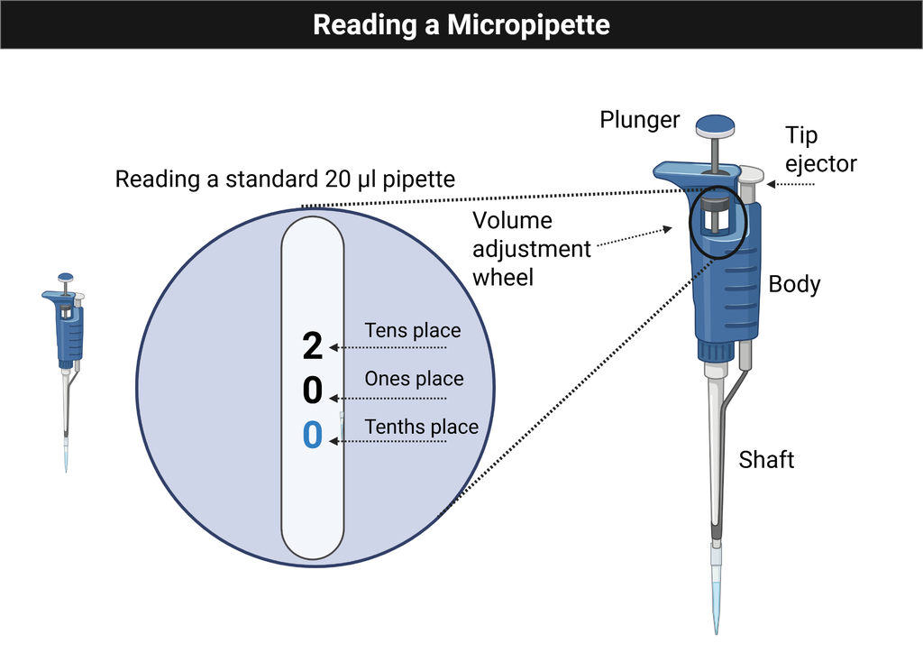

Micropipette volume display for introductory pipetting practice.

- Add correct volume to each circle — keep drops within the circle
- Have each group member try at least two different volumes
- Practice picking up the entire drop without leaving liquid behind

## Methods: Volume Challenge

- Each group member attempts three volumes: 5 µL, 20 µL, and 100 µL
- Repeat each volume three times and weigh each drop
- Record mass (mg) in the data table; calculate accuracy and coefficient of variation

## Results & Discussion

- Compare your gravimetric accuracy to the pipette specification (±2%)
- Identify the volume where your group had the most and least variability
- Discuss one adjustment you made to improve consistency

## Reflection Questions

1. Why is reproducibility important when setting up 96-well plate assays?
2. Which pipette type works best for very small volumes (< 2 µL), and why?
3. What did you include in your first ELN entry, and why does structure matter?